# Guida all’uso di Attuario AI Assistant

**Versione 2.2 | Metodi Stocastici Integrati**

## Cosa è Shiny?

Shiny è un framework per R che permette di creare applicazioni web interattive direttamente dal codice R, senza richiedere conoscenze di HTML, CSS o JavaScript. Sviluppato da RStudio (ora Posit), Shiny trasforma le analisi statistiche e i modelli in strumenti interattivi accessibili tramite browser web.

### Caratteristiche principali di Shiny:

- **Reattività**: Gli elementi dell’interfaccia rispondono automaticamente alle azioni dell’utente
- **Visualizzazione dinamica**: I grafici e le tabelle si aggiornano in tempo reale
- **Interfaccia user-friendly**: Controlli intuitivi come slider, pulsanti e menu a tendina
- **Facile da distribuire**: Le app possono essere condivise come URL o incorporate in dashboard
- **Estensibile**: Può integrarsi con CSS, JavaScript e altri framework per applicazioni più complesse

### Come funziona:

1. **Server**: La logica dell’applicazione scritta in R
2. **UI (User Interface)**: I componenti visibili e interattivi
3. **Reattività**: Il sistema che collega input degli utenti e output dell’app

Shiny è ideale per data scientist, ricercatori e analisti che vogliono condividere modelli complessi con colleghi o clienti senza richiedere loro conoscenze di programmazione.

Questa guida vi accompagnerà nell’utilizzo dell’applicazione Attuario AI Assistant per l’analisi dei rischi catastrofali nel ramo danni. L’applicazione integra simulazioni stocastiche con analisi basate su intelligenza artificiale per fornire valutazioni complete dei rischi.

## Indice

1. Panoramica generale
2. Elementi base di un’app Shiny
3. Tab Simulazione
4. Tab Analisi IA
5. Tab Report
6. Caso d’uso completo
7. Troubleshooting
8. Requisiti tecnici

## Panoramica generale

L’Attuario AI Assistant è un’applicazione Shiny che permette di:

- Simulare scenari di rischio con distribuzioni a coda pesante
- Analizzare scenari catastrofali tramite intelligenza artificiale
- Integrare dati di simulazione con analisi IA
- Generare report completi per la gestione del rischio

L’interfaccia è organizzata in tre sezioni principali, accessibili tramite i tab in alto: - **Simulazione**: per generare e analizzare dati di sinistri - **Analisi IA**: per valutare scenari catastrofali - **Report**: per generare documentazione completa

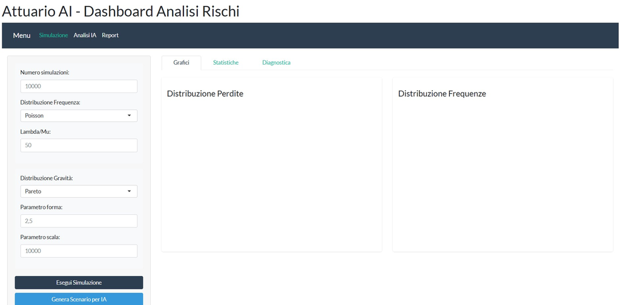

Dashboard Attuario AI

## Elementi base di un’app Shiny

Se non hai mai utilizzato un’applicazione Shiny prima, ecco alcuni concetti fondamentali che ti aiuteranno a comprendere meglio come funziona l’Attuario AI Assistant:

### Interfaccia utente (UI)

L’interfaccia utente di un’app Shiny è costituita da:

- **Input**: Elementi interattivi che permettono all’utente di fornire dati o impostare parametri
  - Campi di testo
  - Slider
  - Menu a tendina
  - Caselle di controllo
  - Pulsanti di azione
- **Output**: Elementi che mostrano i risultati
  - Grafici
  - Tabelle
  - Testo formattato
  - Report scaricabili

### Reattività

La reattività è il concetto chiave di Shiny:

1. L’utente modifica un input (ad esempio, sposta uno slider)
2. Shiny rileva automaticamente la modifica
3. Il server ricalcola i valori dipendenti da quell’input
4. Gli output correlati vengono aggiornati senza ricaricare la pagina

### Navigazione nell’app Attuario AI

L’Attuario AI utilizza un’interfaccia a schede (tab) per organizzare le diverse funzionalità:

- I **tab principali** in alto permettono di passare tra le diverse sezioni dell’app
- All’interno di ogni sezione, possono esserci **sub-tab** per organizzare ulteriormente i contenuti
- I **pulsanti** eseguono azioni specifiche (come avviare una simulazione)
- I **pannelli laterali** contengono i controlli per modificare i parametri
- Il **pannello principale** mostra i risultati delle analisi

Quando utilizzi l’app: 1. Imposta i parametri desiderati nel pannello laterale 2. Clicca sui pulsanti di azione per eseguire calcoli o analisi 3. Visualizza i risultati nel pannello principale 4. Naviga tra i tab per accedere alle diverse funzionalità

## Tab Simulazione

Questa sezione permette di generare simulazioni Monte Carlo per analizzare la distribuzione delle perdite aggregate.

### Parametri disponibili

**Parametri di frequenza**: - **Numero simulazioni**: controlla la dimensione del campione (valori consigliati: 10.000-100.000) - **Distribuzione Frequenza**: determina il modello per il numero di sinistri - **Poisson**: adatta per eventi indipendenti con tasso costante - **Binomiale Negativa**: preferibile quando c’è sovradispersione - **Lambda/Mu**: parametro di intensità per la distribuzione di frequenza

**Parametri di gravità**: - **Distribuzione Gravità**: determina il modello per l’importo dei singoli sinistri - **Pareto**: ottima per modellare code pesanti (eventi estremi) - **LogNormale**: buona per sinistri con asimmetria moderata - **Gamma**: adatta per sinistri con comportamento più regolare - **Parametro forma**: controlla la forma della distribuzione - **Parametro scala**: controlla la scala (grandezza) dei sinistri

### Esempio di configurazione

Per un’analisi realistica di eventi sismici, consigliamo:

| Parametro | Valore | Note |
| --- | --- | --- |
| Numero simulazioni | 10000 | Buon compromesso tra precisione e velocità |
| Distribuzione Frequenza | Poisson | Adatta per eventi rari e indipendenti |
| Lambda/Mu | 35 | Rappresenta una frequenza media annuale realistica |
| Distribuzione Gravità | Pareto | Ideale per catturare eventi estremi |
| Parametro forma | 2.1 | Valore < 2.5 genera code più pesanti |
| Parametro scala | 15000 | Per importi medi dei sinistri più elevati |

### Risultati della simulazione

Dopo aver cliccato su “Esegui Simulazione”, verranno generati:

1. **Grafici**:
   - Distribuzione delle perdite aggregate
   - Distribuzione delle frequenze dei sinistri

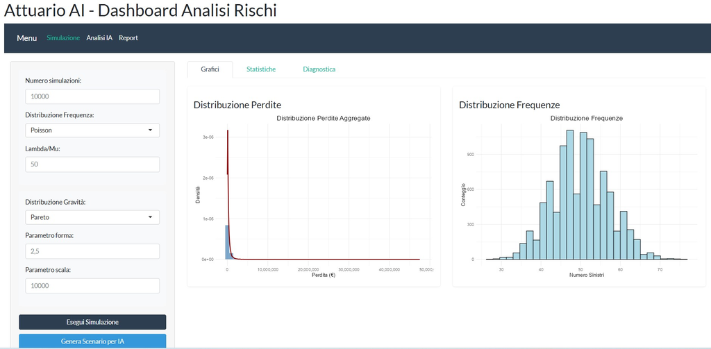

   Tab Simulazione - Grafici

2. **Statistiche**:
   - Media delle perdite
   - Deviazione standard
   - VaR (Value at Risk) al 99.5%
   - TVaR (Tail Value at Risk) al 99.5%
   - Analisi bayesiana (quando applicabile)

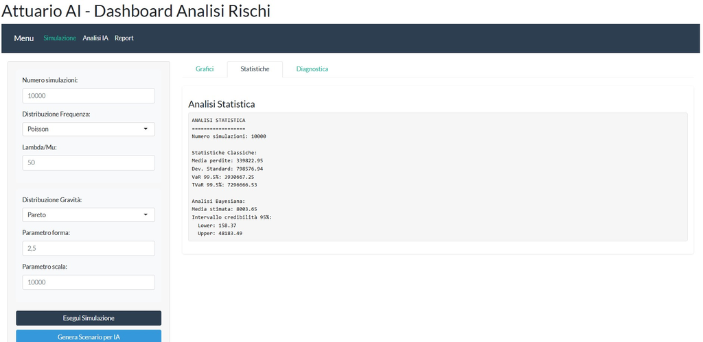

   Tab Simulazione - Statistiche

3. **Diagnostica**:
   - Parametri utilizzati
   - Timestamp della simulazione
   - Dettagli tecnici dell’esecuzione

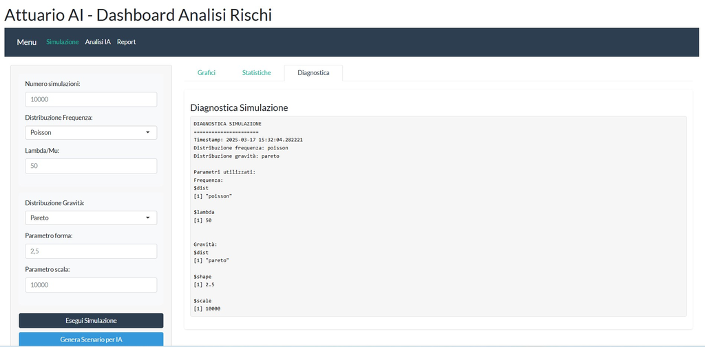

   Tab Simulazione - Diagnostica

## Metodologia di simulazione e analisi bayesiana

### Metodologia della simulazione stocastica

L’Attuario AI Assistant utilizza una metodologia avanzata di simulazione stocastica basata sul modello collettivo del rischio. Questo approccio si articola in:

1. **Modello collettivo del rischio**: La perdita aggregata (S) è modellata come:

   $$S = \sum_{i=1}^{N} X_i$$

   Dove:
   - $N$ è una variabile aleatoria che rappresenta il numero di sinistri (frequenza)
   - $X_i$ sono variabili aleatorie indipendenti e identicamente distribuite che rappresentano l’importo dei singoli sinistri (gravità)
2. **Simulazione Monte Carlo**:
   - Per ogni iterazione, si genera un numero casuale $N$ dalla distribuzione di frequenza selezionata
   - Si generano $N$ valori casuali dalla distribuzione di gravità selezionata
   - Si calcola la somma per ottenere la perdita aggregata
   - Si ripete il processo migliaia di volte per costruire la distribuzione empirica
3. **Distribuzione a coda pesante**: Per modellare eventi catastrofali, l’applicazione utilizza distribuzioni con code pesanti come la Pareto, che seguono l’andamento:

   $$F(x) = 1 -
   \left(\frac{K}{x}\right)^{\alpha} \quad \text{per } x \geq
   K$$

   Dove:
   - $\alpha$ è il parametro di forma (più piccolo è $\alpha$, più pesante è la coda)
   - $K$ è il parametro di scala

### Analisi bayesiana in dettaglio

L’analisi bayesiana implementata nell’Attuario AI Assistant permette di incorporare informazioni a priori e aggiornare le stime in base ai dati osservati. Il processo comprende:

#### Fondamenti teorici

L’inferenza bayesiana si basa sul teorema di Bayes:

$$P(\theta|X) \propto P(X|\theta) \times
P(\theta)$$

Dove: - $P(\theta|X)$ è la distribuzione a posteriori dei parametri $\theta$ dato i dati $X$ - $P(X|\theta)$ è la verosimiglianza dei dati dato i parametri - $P(\theta)$ è la distribuzione a priori dei parametri

#### Implementazione nell’Attuario AI

1. **Distribuzione a priori**: Per i parametri di gravità, l’applicazione utilizza distribuzioni a priori debolmente informative basate su conoscenze attuariali generali.
2. **Aggiornamento**: I parametri vengono aggiornati in base ai dati simulati, dando maggior peso alle osservazioni più recenti.
3. **Distribuzione a posteriori**: Viene calcolata utilizzando tecniche di approssimazione o metodi di simulazione MCMC semplificati.
4. **Intervallo di credibilità**: A differenza degli intervalli di confidenza frequentisti, gli intervalli di credibilità bayesiani (visibili nell’output dell’applicazione) rappresentano direttamente la probabilità che il parametro si trovi all’interno dell’intervallo.

#### Vantaggi dell’approccio bayesiano

- **Robustezza**: Particolarmente utile quando i dati sono limitati o hanno code pesanti
- **Interpretabilità**: Gli intervalli di credibilità hanno un’interpretazione probabilistica diretta
- **Flessibilità**: Permette di incorporare conoscenze specialistiche attraverso le distribuzioni a priori
- **Calibrazione con IA**: L’analisi bayesiana si integra naturalmente con i modelli di IA per migliorare le stime di impatto

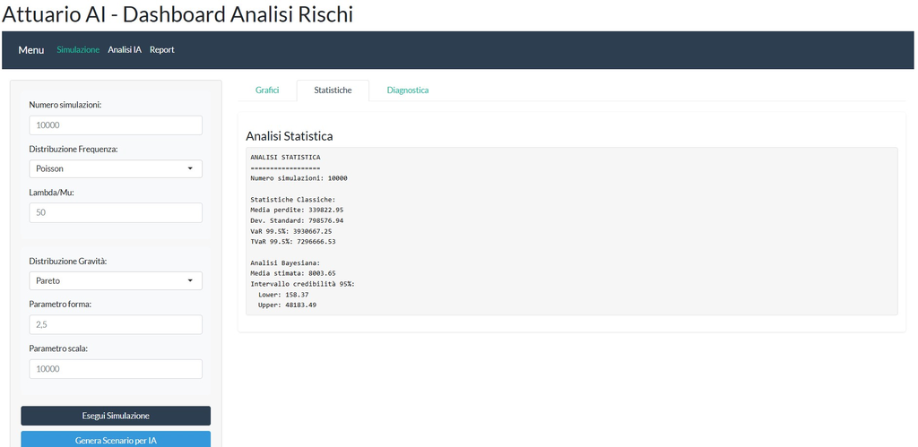

Analisi Bayesiana

Quando visualizzi i risultati nell’applicazione, l’analisi bayesiana fornisce stime più conservative e robuste rispetto all’analisi classica, particolarmente utili per la gestione dei rischi catastrofali dove gli eventi estremi possono avere impatti significativi.

## Tab Analisi IA

Questa sezione utilizza modelli di intelligenza artificiale per analizzare scenari catastrofali e stimare probabilità e impatti potenziali.

### Parametri dell’analisi

- **Scenario Catastrofale**: descrizione testuale dello scenario da analizzare
- **Modello IA**: selezione del modello di intelligenza artificiale
  - **llama-3.3-70b-versatile**: modello principale, bilancia accuratezza e velocità
  - **mixtral-8x7b-32768**: alternativa per analisi più rapide
  - **gemma-7b-it**: opzione leggera per analisi preliminari
- **Temperatura**: controlla la creatività dell’output (valori bassi = più deterministico)
- **Utilizza dati simulazione**: integra i risultati della simulazione nell’analisi IA

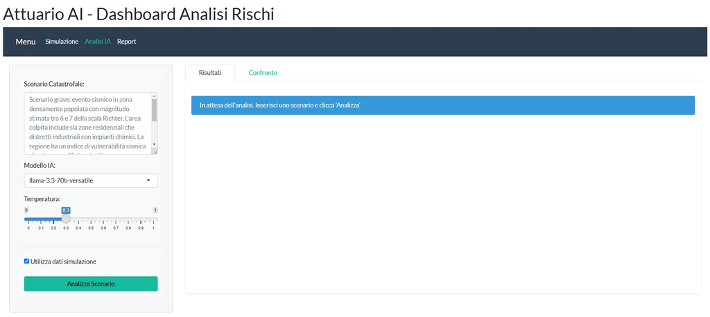

Tab Analisi IA - Input

### Esempio di scenario

Per testare tutte le funzionalità, consigliamo questo scenario sismico:

[output not shown]

### Risultati dell’analisi IA

Dopo aver cliccato su “Analizza Scenario”, verranno generati:

1. **Risultati testuali**:
   - Tipo di evento identificato
   - Probabilità stimata dell’evento
   - Impatti potenziali (minimo, più probabile, massimo)
   - Raccomandazioni per la mitigazione del rischio
2. **Visualizzazione grafica**:
   - Grafico a barre degli impatti economici potenziali
   - Confronto con i risultati della simulazione (se disponibili)

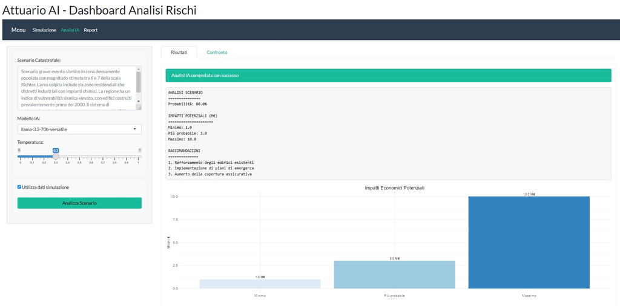

Tab Analisi IA - Risultati

### Confronto con la simulazione

Nella scheda “Confronto” è possibile visualizzare una comparazione tra i risultati della simulazione e quelli dell’analisi IA, evidenziando eventuali discrepanze o conferme tra i due approcci.

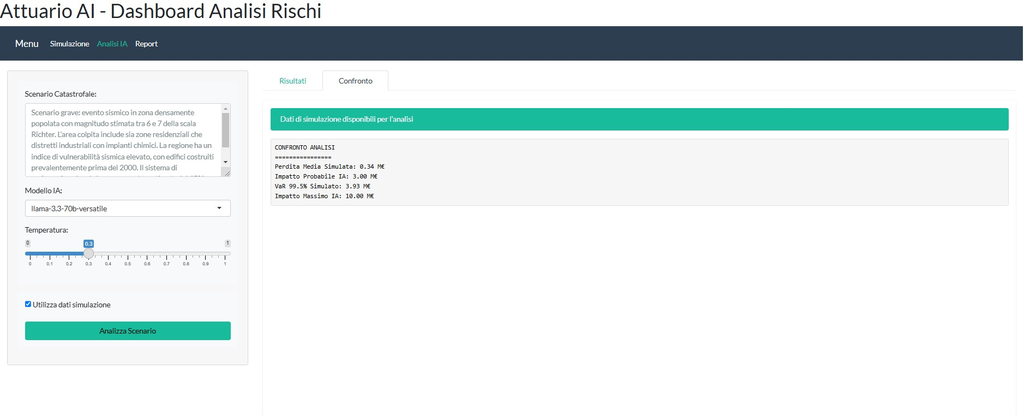

Tab Analisi IA - Confronto

## Tab Report

Questa sezione permette di generare report completi che integrano i risultati della simulazione e dell’analisi IA.

### Opzioni del report

- **Tipo Report**:
  - **Completo**: include tutte le sezioni (dati, simulazione, IA, confronto, raccomandazioni)
  - **Sintetico**: versione ridotta con focus su risultati e raccomandazioni
  - **Tecnico**: dettagli tecnici della simulazione e dell’analisi per esperti

### Generazione del report

1. Selezionare il tipo di report desiderato
2. Visualizzare l’anteprima nella schermata principale
3. Cliccare su “Genera Report” per scaricare il documento HTML

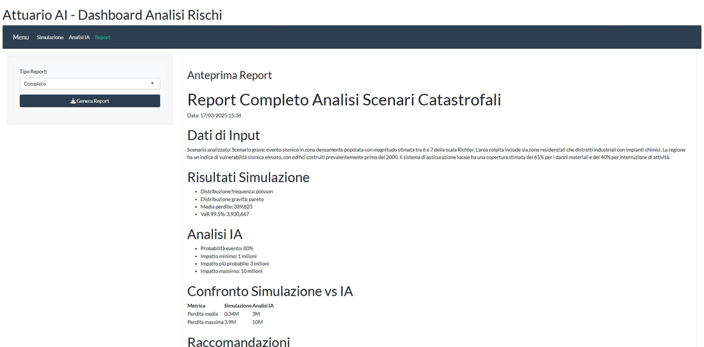

Tab Report - Anteprima

## Caso d’uso completo

Di seguito, vi guidiamo attraverso un caso d’uso completo che illustra tutte le funzionalità dell’applicazione:

### Passo 1: Configurazione e simulazione

1. Accedere alla tab **Simulazione**
2. Impostare i parametri come da tabella:

   | Parametro | Valore |
   | --- | --- |
   | Numero simulazioni | 10000 |
   | Distribuzione Frequenza | Poisson |
   | Lambda/Mu | 35 |
   | Distribuzione Gravità | Pareto |
   | Parametro forma | 2.1 |
   | Parametro scala | 15000 |

3. Cliccare su “Esegui Simulazione”
4. Esplorare i risultati nei tab Grafici, Statistiche e Diagnostica
5. Cliccare su “Genera Scenario per IA” per creare automaticamente uno scenario basato sui risultati

### Passo 2: Analisi IA

1. Nella tab **Analisi IA**, verificare lo scenario generato o sostituirlo con lo scenario di esempio
2. Impostare:
   - **Modello IA**: llama-3.3-70b-versatile
   - **Temperatura**: 0.3
   - **Utilizza dati simulazione**: Sì
3. Cliccare su “Analizza Scenario”
4. Esplorare i risultati dell’analisi e il confronto con la simulazione

### Passo 3: Generazione del report

1. Accedere alla tab **Report**
2. Selezionare **Tipo Report**: Completo
3. Verificare l’anteprima del report
4. Cliccare su “Genera Report” per scaricare il documento HTML

## Troubleshooting

### Problemi comuni e soluzioni

| Problema | Possibile causa | Soluzione |
| --- | --- | --- |
| Errore nell’esecuzione della simulazione | Parametri non validi | Verificare che tutti i parametri siano positivi e nel range corretto |
| Errore nell’analisi IA | API key non configurata o errata | Verificare l’impostazione dell’API key di Groq |
| Modalità simulazione attiva | API key non disponibile | È normale, l’app utilizza un modello interno semplificato |
| Report non generato | Dati mancanti | Assicurarsi di aver eseguito sia la simulazione che l’analisi IA |
| Valori irrealistici nelle stime | Parametri di distribuzione estremi | Regolare i parametri di forma e scala a valori più realistici |

### Log e diagnostica

Per problemi più complessi, consultare il file di log in:

```
[tempdir]/attuario_ai.log
```

## Requisiti tecnici

### Pacchetti R richiesti

L’applicazione richiede i seguenti pacchetti R: - actuar - dplyr - ggplot2 - rstanarm - groqR - jsonlite - rmarkdown - shiny - scales - future - promises - bslib

### Configurazione API

Per utilizzare l’analisi IA tramite API esterna, è necessario: 1. Ottenere una chiave API Groq 2. Configurarla come variabile d’ambiente: `R Sys.setenv(GROQ_API_KEY = "la_tua_chiave_api")`

### Hardware consigliato

Per prestazioni ottimali con simulazioni estese: - CPU: 4+ core - RAM: 8+ GB - Spazio disco: 1+ GB libero